# The ISBA Bulletin

June 2026 - Vol. 33 No. 2

# MESSAGE FROM THE PRESIDENT

Antonio Lijoi

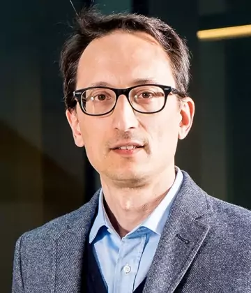

Welcome to the second ISBA Bulletin of 2026!

By the time this issue reaches you, the event many of us have been looking forward to for the past two years will be just around the corner: the ISBA World Meeting in Nagoya. As I write these lines, preparations are entering their final stages, and this seems like the perfect opportunity to thank all those who have contributed to making this meeting possible. Local organizers, members of the Scientific Committee and the Committee on Named Lectures, the ISBA Administrator, the ISBA Executive Committee, and the many volunteers serving on committees and award panels have all devoted a tremendous amount of time and energy to this event. If I am forgetting someone, my apologies, but I really want to emphasize that the success of this meeting is truly the result of a collective effort across the Society.

And what a meeting it promises to be. With 874 registered participants one week before the start of the conference, Nagoya will become the largest in-person ISBA World Meeting ever organized. This is a remarkable milestone for our community. It is worth remembering that the first World Meeting, held in Valencia in 1993, attracted around 200 participants. The growth of ISBA over the past three decades has been extraordinary, and the Nagoya meeting is yet another sign of the vitality of our community.

The scientific program reflects this vitality. Participants will enjoy 61 invited sessions, 9 contributed sessions, and 386 posters distributed across three poster sessions. We will hear the de Finetti Lecture by Peter Müller, the 2024 and 2026 Bayarri Lectures by Stéphanie van der Pas and Daniele Durante, respectively, and Foundation Lectures by Sylvia Richardson, David Dunson, Hal Stern, and Sid Chib. Barbara Engelhardt, Botond Szabó, Fumiyasu Komaki, and Emtiyaz Khan will deliver keynote talks. The meeting will also feature a short course on Bayesian Deep Learning by Julyan Arbel, the always highly anticipated Savage Award sessions, and the poster sessions, which remain among the best opportunities to discover new ideas and meet emerging researchers.

Nagoya will also provide an opportunity to remember colleagues who have left a lasting mark on our community. The program includes memorial sessions honoring Harry van Zanten and Herman van Dijk, whose scientific contributions and personal generosity will be greatly missed.

Continuing a long-standing ISBA tradition, we were able to support the participation of early-career scholars and PhD students from our community. Thanks to our sponsors, 97 participants have received financial support to attend the meeting. Encouraging the participation of students and young researchers remains one of the most important investments we can make in the future of our Society.

Of course, World Meetings are about much more than scientific talks. They are opportunities to reconnect with old friends, meet new colleagues, and strengthen the sense of community that has always characterized ISBA. I hope many of you will join the Welcome Reception on June 28 and the Banquet on July 3, where we will celebrate the achievements of our award recipients and newly elected Fellows. I would also encourage you to attend the ISBA General Assembly on July 2, where we will discuss the activities and future directions of the Society.

Another event of interest is the lunch session on the Future of ISBA Meetings. The session will present the results of the survey conducted by the *ad hoc* committee on this topic. I would like to thank Guido Consonni, Kate Lee, Gertraud Malsiner-Walli, and Christian Robert for their thoughtful work. As our community continues to grow, questions of accessibility, sustainability, and inclusiveness become increasingly important, and the survey provides valuable guidance for future discussions. You will find further details in the article contributed by the committee in this issue of the Bulletin.

As always, the World Meeting will be surrounded by a number of satellite events. Immediately before Nagoya, Chiba University will host the *10th Bayesian Young Statisticians Meeting* (BAYSM 2026). After the conference, participants will have the opportunity to attend the meeting on *Information Geometry, Privacy, and Monte Carlo* at the Institute of Statistical Mathematics in Tokyo, as well as the *4th BNP Networking Conference* at the University of Seoul.

Whether you are joining us in Nagoya or are unable to attend this year, I hope you enjoy this issue of the Bulletin. For those traveling to Japan, I wish you a safe journey and look forward to seeing you very soon. For those who cannot be with us this time, I hope to meet you at a future ISBA event.

# FROM THE EDITOR

Francesco Denti

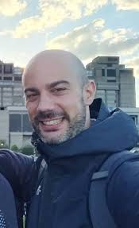

Hello, ISBA community!

June is drawing to a close, the World Meeting is just around the corner, and it is time for the second issue of the ISBA Bulletin for 2026.

This issue is packed with news and updates from across the ISBA community. In particular, we look forward to gathering in Nagoya for the World Meeting, which promises an exciting scientific program and a valuable opportunity to reconnect with colleagues and friends from around the world.

As usual, you’ll find information on upcoming conferences and workshops, announcements from ISBA Sections, opportunities for students and early-career researchers, recent achievements of our members, and much more.

I hope you enjoy this issue, and I look forward to seeing many of you in Nagoya soon!

# FROM THE PROGRAM COUNCIL

Yang Ni

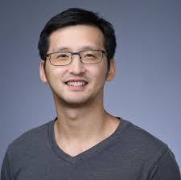

**(Co)-sponsorship & Endorsement Requests.** If you are planning a meeting and would like to request financial sponsorship (or co-sponsorship) or non-financial endorsement from ISBA, please submit your request to the Program Council at program-council@bayesian.org. Detailed information on how to submit requests for sponsorship or endorsement is available [here](https://bayesian.org/events/request-sponsorshipendorsement/).

# UPDATES FROM BA

Igor Prünster

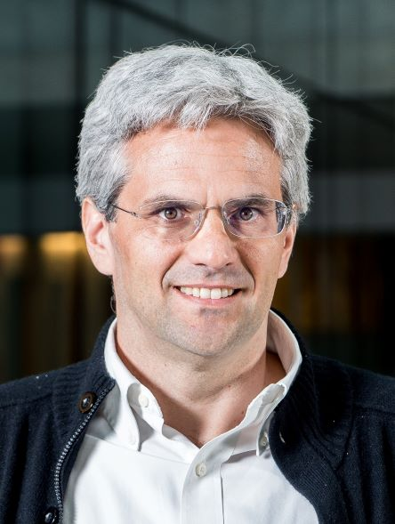

In view of the ISBA World Meeting in Nagoya, I am pleased to share a few updates on *Bayesian Analysis*.

### 2025 Submissions and Review Times

The first message is that submissions to the journal continue to increase. In 2025, *Bayesian Analysis* received 327 submissions overall, the highest number in the history of the journal and above the levels reached during the COVID-19 years. The first five months of 2026 suggest that the upward trend is continuing, with the journal projected to receive slightly more than 400 submissions for the full year.

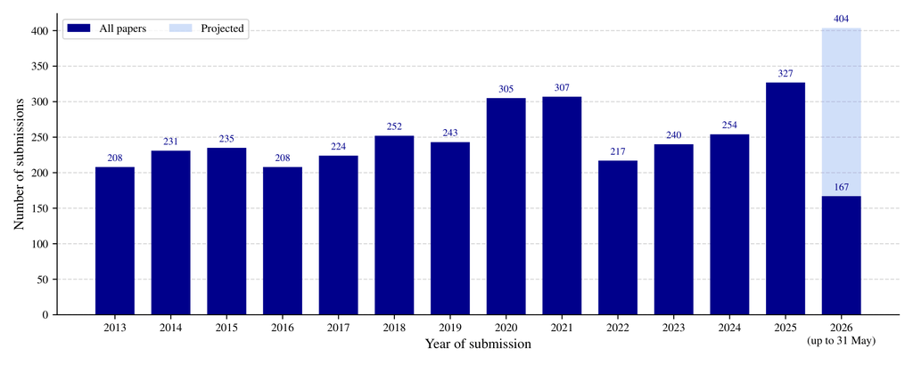

Figure 1: Submissions to Bayesian Analysis over time. The first 2026 bar reports submissions received up to 31 May; the second gives the corresponding full-year projection.

This is a very positive sign for the journal. It reflects the central role of *Bayesian Analysis* in the Bayesian community and the continuing vitality of our field. At the same time, it creates a substantial workload for Co-Editors, Associate Editors, and Referees. Maintaining high editorial standards while keeping turnaround times predictable is therefore one of our main operational priorities.

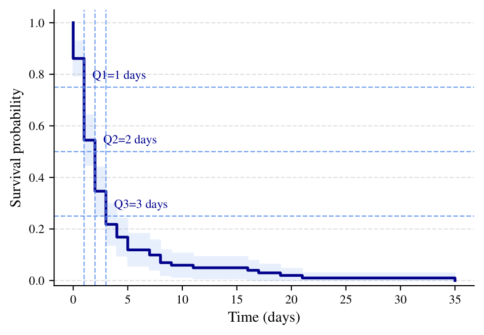

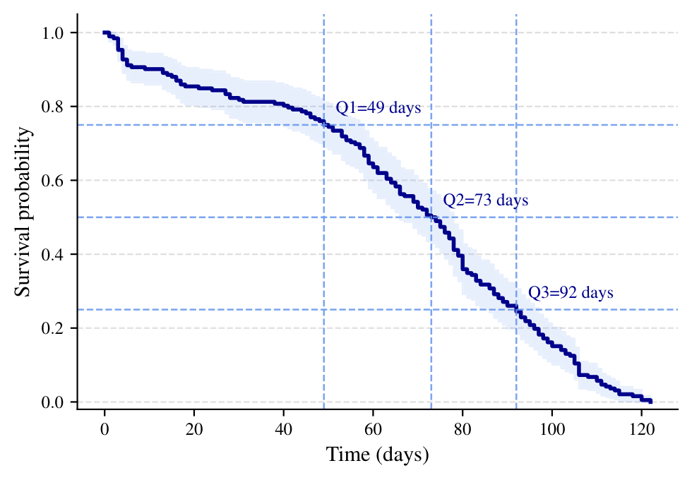

Figure 2: Empirical survival curves for time to first decision for submissions received in 2025, separately for desk decisions and submissions sent to Associate Editors.

Desk decisions were typically reached within a few days, reflecting an effort to provide rapid initial screening. For papers sent to Associate Editors, the median time to first decision was 73 days. All submissions received in 2025 have received a first decision within the four-month window, and I am glad to report that this target has continued to be met for submissions received through February 2026.

These figures should not be read as prioritizing speed over quality. The strength of *Bayesian Analysis* has always been the combination of careful editorial judgment and constructive feedback. The main objective is instead to avoid outliers in decision times and to give authors greater predictability about the editorial timeline. I thank our Managing Editor, Francesco Sanna Passino, for his careful work in assembling the editorial data.

The increase in submissions, combined with the ambitious four-month target, means that we rely more than ever on the support of the Bayesian community. I am especially grateful to the Co-Editors, Associate Editors, and Referees for their collective work. I hope that many of you will continue to help the journal by reviewing papers when asked and by providing careful and timely reports.

### Lindley Prize

Let me also remind readers of the call for papers for the 2026 Lindley Prize. The prize is awarded for innovative research in Bayesian statistics. Eligible papers must be presented at the ISBA 2026 World Meeting in Nagoya and accepted for publication in *Bayesian Analysis*. Submissions are welcome from any presenter, whether invited or contributed, for oral or poster presentations. Papers should be submitted electronically to *Bayesian Analysis* by September 30, 2026, indicating in the cover letter that the manuscript is being submitted for the Lindley Prize and including the identification number of the session in which the work was presented. Further information is available on the [Lindley Prize webpage](https://bayesian.org/project/lindley-prize/).

The winner of the 2024 Lindley Prize will be announced during the conference banquet and awards ceremony, which will be held in the evening of Friday, July 3, 2026.

### *Bayesian Analysis* at the ISBA World Meeting

I also hope to see many of you at the *Bayesian Analysis Highlights* session at the ISBA World Meeting in Nagoya, scheduled for 9:00 am on Friday, July 3, 2026. The session will showcase the following three *Bayesian Analysis* papers:

- Sudipto Banerjee (University of California, Los Angeles)  
  *Bayesian inference for spatial-temporal non-Gaussian data using predictive stacking*  
  Joint work with S. Pan, L. Zhang, and J. R. Bradley
- Kolyan Ray (Imperial College London)  
  *Group Spike-and-Slab Variational Bayes*  
  Joint work with M. Komodromos, M. Evangelou, and S. Filippi
- Subhashis Ghosal (North Carolina State University)  
  *Bayesian Semi-supervised Multi-category Classification under Nonparanormality*  
  Joint work with R. Zhu and S. Ghosh.

### Advance Publication

Readers visiting the [Advance Publication section](https://projecteuclid.org/journals/bayesian-analysis/advance-publication) will also notice an update to the journal’s presentation: newly accepted *Bayesian Analysis* papers appear with the updated reference format. I hope you will like the cleaner presentation, and that it will also encourage you to browse the many excellent papers that have recently appeared in the journal.

# REPORT BY THE AD HOC COMMITTEE ON THE FUTURE OF ISBA CONFERENCES

Guido Consonni, Kate Lee, Gertraud Malsiner-Walli, and Christian Robert

During the ISBA 2024 World Meeting in Venice, an invited panel discussion titled *“Which Future for ISBA Conferences?”* was organized by Guido Consonni and Gertraud Malsiner-Walli. The panelists were Kate Lee, Christian Robert, and Ron Wasserstein. Despite the presence of many parallel sessions, the panel attracted a substantial audience, including ISBA President Aad van der Vaart, and generated a lively discussion on the future of scientific meetings within the Bayesian community. The strength of that discussion suggested that questions about conference formats, access, environmental sustainability, and community building had become timely for ISBA.

In September 2025, the ISBA Executive Committee established the *Ad Hoc Committee on the Future of ISBA Conferences*, with the task of preparing a report on the environmental impact and inclusivity of ISBA meetings, and of exploring possible directions for future conference formats. The Committee consisted of Guido Consonni, Kate Lee, Gertraud Malsiner-Walli, and Christian Robert. Its aim was not to prescribe a single model for future meetings, but to assemble evidence and identify issues that deserve consideration by the Society.

The Committee examined a broad range of issues related to contemporary scientific meetings, with particular attention to inclusive participation and environmental sustainability. Different formats were considered, including in-person, virtual, hybrid, and multi-hub meetings. Each of these formats offers opportunities and raises difficulties. The Committee also considered it essential to obtain direct feedback from ISBA members. To this end, it organized the *Survey on Meeting Experiences to Inform Future ISBA Events*. All ISBA members were invited to participate, and responses were collected between January 5 and March 31, 2026.

The full report is organized into four main sections. The first summarizes the survey results. The second discusses the environmental impact of conferences. The third considers inclusiveness and barriers to participation. The fourth focuses on multi-hub conferences, a format still relatively unfamiliar in many scientific communities but, in the Committee’s view, worthy of serious consideration. The sections on environmental impact, inclusiveness, and multi-hub meetings each include a discussion of implications for ISBA. The report also contains an appendix with the survey questionnaire and additional material on past meetings and conference-related evidence.

### Survey results

The survey collected 221 responses. Questions 1–11 were closed-ended and provided a quantitative overview of motivations for attending ISBA meetings, perceived advantages and drawbacks of different formats, barriers to participation, environmental considerations, and preferences for future meetings. Questions 12–14 were open-ended and invited respondents to elaborate on inclusiveness, accessibility, environmental sustainability, and other aspects of future ISBA events. The number of open-text responses was 83 for Q12, 66 for Q13, and 56 for Q14.

The closed-ended responses show that ISBA meetings are primarily valued as occasions for scientific exchange, research presentation, networking, and participation in the Bayesian community. Respondents emphasized learning about new developments, presenting their own work, meeting collaborators, building visibility, and maintaining professional connections. These findings are important because they clarify that members attend ISBA meetings not only to receive scientific information, but also to take part in the informal and social processes through which a scientific community is built.

At the same time, the survey identifies a clear trade-off between the strengths of in-person meetings and the advantages of remote participation. In-person meetings are strongly associated with networking, social interaction, engagement, focus, and more natural scientific discussion. Virtual participation is valued for reducing financial and administrative costs, eliminating or reducing travel, improving accessibility, and being more environmentally friendly. However, respondents also identified substantial drawbacks of virtual formats, including weaker networking, lower engagement, less effective informal discussion, and time-zone difficulties.

The resulting message is that in-person meetings remain the most strongly supported format, while fully virtual meetings are most often identified as the least preferred option. Hybrid and multi-hub formats occupy an intermediate position. Their possible appeal lies in the prospect of combining some local or regional in-person interaction with broader access and reduced travel burden.

The open-ended responses provide a richer view of these issues. Q12 asked: *“What changes would you recommend to make future ISBA events more inclusive and accessible for international attendees and individuals from all backgrounds?”* Q13 asked: *“What changes would you recommend to make future ISBA events more environmentally friendly but accessible for international attendees and individuals from all backgrounds?”* Q14 invited respondents to elaborate further on any of the preceding questions. Each open-ended response allowed a maximum of 1000 characters.

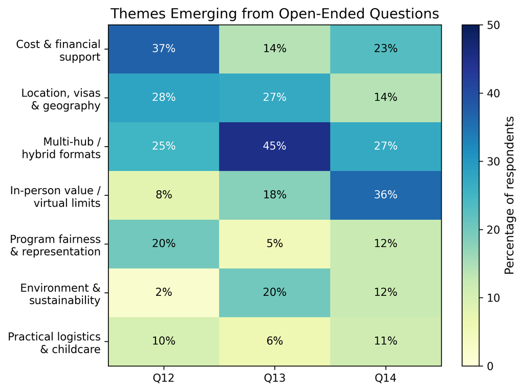

Figure 3: Themes emerging from the open-ended questions Q12–Q14. Cell entries are approximate coded percentages, using the number of responses to each question as the denominator. Categories overlap.

The dominant theme in Q12 was financial accessibility. Respondents repeatedly mentioned registration fees, accommodation, travel costs, and the need for more travel awards or fee reductions. Several comments proposed sliding-scale registration, need-based support, lower-cost venues, and more systematic travel funding. A second major theme concerned geographic accessibility, including visa barriers, travel distance, political restrictions, and the importance of choosing locations that are easier to reach and safer for a wider range of participants.

Q13 was dominated by environmental sustainability and by the search for compromise formats. Respondents often mentioned multi-hub meetings as a possible way to reduce long-distance travel while preserving some benefits of in-person interaction. Suggestions included regional hubs, linked plenaries, local streams, and satellite events organized around a main meeting. Respondents also emphasized practical decisions such as choosing well-connected locations, reducing single-use materials, simplifying catering, and collecting information on the travel footprint of ISBA meetings.

Q14 reinforced the perceived value of in-person meetings. Respondents emphasized networking, scientific serendipity, poster interaction, focused time away from ordinary work, and the importance of conferences for early-career researchers. At the same time, they recognized that the current in-person model can generate equity problems if only those with strong institutional support can afford regular participation. Taken together, the survey suggests that the challenge is not to replace in-person meetings, but to broaden access to the scientific and social benefits that make them valuable.

### Environmental impact of conferences

Academic and professional conferences generate substantial greenhouse gas emissions, especially through travel. The report reviews evidence showing that the carbon footprint of major scientific meetings can be substantial, particularly when participants travel long distances by air. In the context of ISBA, whose membership is international, these issues play a significant role.

The environmental argument does not point to a single obvious solution. Fully in-person meetings maximize traditional face-to-face interaction, but tend to generate the highest travel-related emissions. Fully virtual meetings offer the strongest environmental benefits and may broaden access, but they are often less effective for informal exchange, mentoring, and community building. Hybrid and multi-hub formats occupy an intermediate position, potentially reducing emissions while preserving some benefits of physical presence.

For ISBA, this suggests that future conferences should be evaluated in terms of explicit trade-offs. Environmental considerations should be interpreted together with members’ preferences, professional needs, and practical constraints. Measures such as careful site selection, encouragement of lower-emission transport where feasible, reduced waste, remote access to selected components, and exploration of regional hubs could all contribute to more sustainable conference planning. The point is not to eliminate travel altogether, but to consider more deliberately when long-distance travel is essential and when it could be reduced or reorganized.

### Inclusiveness

The report considers inclusiveness as a structural issue in conference design. Conferences provide valuable opportunities to exchange ideas, build networks, and present research. Both in-person and virtual formats can create barriers to participation.

In-person meetings can involve substantial costs, including registration fees and travel-related expenses. Financial barriers were the most frequently reported concern in our survey.

Other administrative, logistical, or personal factors, including complex visa procedures, caregiving responsibilities, health conditions, and accessibility needs, may further restrict attendance. Virtual access reduces some of these barriers, but introduces substantial time-zone difficulties, lower visibility for remote presenters, and fewer opportunities for spontaneous discussion and networking outside formal sessions. These concerns have been clearly identified in our survey responses.

Inclusiveness also concerns conference culture and program design. Language differences, unfamiliar conference norms, and overly critical environments can discourage participation. programs may give more visibility to some institutions, regions, topics, career stages, or established networks than to others. Inclusive speaker selection, transparent program procedures, broader representation in invited sessions, and attention to early-career participation are central to how a scientific society shapes its community.

For ISBA, the implications are direct. Recent meetings have already introduced practices such as travel support, childcare support, and attention to sustainable conference practices. These efforts are valuable. At the same time, the growth of Bayesian research and the increasing scale of participation place pressure on existing program structures. Recent meetings have seen growing competition for talk slots. When talk slots are scarce, competition for visibility intensifies, and poster sessions may become overloaded or uneven.

The report therefore suggests that inclusiveness should be treated as an ongoing responsibility involving affordability, accessibility, program design, speaker representation, and community culture.

### Multi-hub meetings

A multi-hub meeting is not simply a virtual meeting. It is a distributed conference in which participants meet in two or more physical locations, with some degree of coordination across hubs. Depending on the design, hubs may share plenary sessions, stream selected talks, organize local sessions, coordinate poster events, or combine synchronous and asynchronous discussions. The format aims to retain some face-to-face interaction while reducing the need for all participants to travel to a single location.

Multi-hub meetings are attractive because they address several concerns at once. They may reduce long-distance travel and therefore emissions. They may lower costs for participants who can attend a regional hub rather than a distant main meeting. They may reduce visa barriers when hubs are chosen to improve accessibility. They may also create more opportunities for regional scientific communities, early-career researchers, and participants who would otherwise be unable to attend.

However, the report emphasizes that multi-hub meetings are not a simple technical fix. They require careful design. Fee distribution between central and local organizers must be addressed. Scientific committees need to avoid reproducing the same concentration of influence in a distributed format. Invited sessions and plenaries must be planned so that the meeting remains scientifically coherent. Time zones create unavoidable difficulties, especially for fully synchronous events. Technological reliability, recording, captions, asynchronous discussion, and clear communication of schedules are essential.

Table 1: Key components of multi-hub/mirror academic conference design.

| Dimension | Key challenge | Leading practice |
| --- | --- | --- |
| **Fee distribution** | Balancing central and local costs | Tiered fees by country income level, combined with a negotiated hub revenue share |
| **Scientific committees** | Geographic concentration of power | Distributed, regionally representative sub-committees with rotating leadership |
| **Invited sessions** | Reproducing existing networks | Open calls; cross-hub sessions; multilingual and region-specific sessions |
| **Inclusiveness** | Assumed rather than actively designed | Explicit representation targets, live captioning, automatic fee waivers |
| **Time zones** | No single schedule works for all | Defined overlap windows, follow-the-sun rotation, and asynchronous fallback |
| **Visa issues** | Single-country bottleneck | Hub locations chosen for visa accessibility; contingency remote participation |

The report notes that some experiments related to ISBA activities have already occurred. The 2021 virtual ISBA World Meeting was mirrored in Marseille, and the workshop *ABC in Svalbard* was relocated across several sites during the COVID-19 period. A secondary hub is also planned in Aussois in connection with BayesComp 2027 in Texas, partly to support potential participants unable to attend the main location. These examples suggest that distributed formats can be explored gradually rather than adopted all at once as a complete replacement for existing meetings.

For ISBA, the multi-hub model deserves serious consideration as a possible compromise between the value of in-person meetings and the need for broader access and reduced environmental impact. Ultimately, its success would depend on the engagement of the whole community, including ISBA sections, program committees, local organizers, and participants.

### Conclusion

The survey confirms the continuing importance of in-person interaction for scientific exchange, networking, informal discussion, mentoring, and community building. At the same time, it documents concerns about affordability, visa access, geographic barriers, environmental impact, and the inclusiveness of conference programs. These concerns are not peripheral to conference planning: they shape who is able to participate in ISBA meetings and how fully different parts of the Bayesian community can contribute to the life of the Society.

The Committee hopes that this report may contribute to future discussions on how ISBA meetings can continue to foster scientific exchange and community building while becoming more inclusive, accessible, and environmentally sustainable.

# JUNIOR ISBA

Francesca Panero

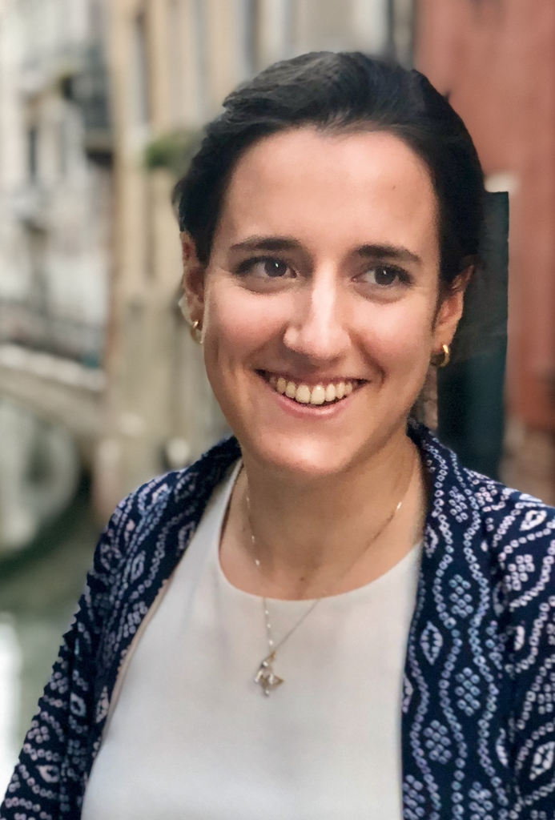

Dear ISBA community,

welcome back to the j-ISBA news! Let us start with a refresher of the not-so-new news, but still relevant:

- [BAYSM 2026](https://baysm2026.github.io) is around the corner: we will see the many participants on June 26 and 27 in Chiba, Japan. We will gain research insights from the keynote speakers Kerrie Mengersen and Kengo Kamatani, 12 talks with discussion by Mike West, Shonosuke Sugasawa and Kaoru Irie, and 52 posters. Prizes will be awarded to the best talks and posters, so be shiny!
- [The Blackwell-Rosenbluth Award](https://j-isba.github.io/blackwell-rosenbluth.html) applications are open until July 12. Remember to nominate your favorite junior Bayesian (who could be yourself!).

### j-ISBA mixer at ISBA

During ISBA, we will hold a j-ISBA event to spend some time all together, get to know nice people, and announce the next activities of j-ISBA. The j-ISBA mixer will happen on Wednesday at 8pm, after the poster session. One drink and some snacks are on us, and additional food and drinks can be purchased in the bar.

The event is limited by space constraints, and we will operate on a first-come, first-served basis. You will receive an email notification with the location address at the beginning of the ISBA week. To participate, please [fill in this form](https://docs.google.com/forms/d/e/1FAIpQLSekARMW_oYs0rS5iWmNuD-8dmzVzEqdqMFJl0uRAb0TJGrj4w/viewform?usp=dialog) before Sunday, June 28th.

### j-ISBA is looking for officers!

In the next ISBA elections, the j-ISBA board will need two new board members to fill the positions of Chair-Elect and Treasurer for the years 2027-2028. I can tell you firsthand that serving on the board is a really rewarding and exciting experience. Senior PhD students, postdocs, and early career researchers are encouraged to apply. Those interested in being nominated for the elections are invited to submit a CV and a motivation letter to jisba.section@gmail.com. To be given full consideration, please limit your motivation letter to 2 pages and submit your materials by July 15, 2026.

# FROM THE BAYESIAN SOCIAL SCIENCES SECTION

Adrian Raftery, Monica Alexander, Nial Friel, Robin Ryder, Eric-Jan Wagenmakers

Officially approved in 2025, the [Bayesian Social Sciences Section](https://bayesian.org/sectionschapters/bayesian-social-sciences/) of ISBA aims to promote the research, application, and dissemination of Bayesian inference for problems in the Social Sciences and Humanities. This domain is extremely broad and includes fields such as Anthropology, Archaeology, Demography, Economics, Geography, History, Linguistics, Political Science, Psychology, and Sociology.

The impetus for the Social Sciences Section was originally provided by two successful workshops titled [Bayesian Methods for the Social Sciences](https://bayesforshs.sciencesconf.org/). BMSS I was held in Paris, October 2022, and featured presentations on social networks, demography, linguistics, emotion, climate change, migration, and mortality. BMSS II took place in Amsterdam, October 2024, and included work on graphical modeling, language change, model selection, social hierarchies, demography, and hypothesis testing. See [this link](https://bayesforshs2.sciencesconf.org/) for more information. Both BMSS I and II followed the same template: the first day was reserved for longer tutorial sessions, preparing participants for the more detailed presentations that took place during the two remaining days. Each workshop also featured a poster session with lively discussion and interaction.

After BMSS II we were not only encouraged by the quality of the presented work, but we also realized that similar methodologies were being used to attack seemingly different topics. Consequently, we felt that superficially distinct application domains in the Social Sciences could benefit from more Bayesian cross-fertilization. Therefore, we resolved to make the BMSS series a tradition and to solidify our resolve by founding an ISBA Social Sciences Section. The main work of this section so far has been to set up BMSS III in Dublin, and our first session on Bayesian Social Sciences will take place at the 2026 ISBA World Meeting in Nagoya, Japan. We hope to see you there!

#### Join us in Dublin

The third installment of *Bayesian Methods for the Social Sciences* will be held at University College Dublin from December 9-11, 2026. The format of the workshop will follow similar lines to the previous two meetings. On the first day, tutorials will be presented on *Bayesian methods in Political Science* (by Max Goplerud, University of Texas at Austin), on *Bayesian methods for pairwise and ranked data* (by Nial Friel, University College Dublin), and on *high-dimensional Bayesian model choice* (by David Rossell, Universitat Pompeu Fabra, Barcelona). We will open registration for the workshop in the coming weeks, and further details, including the speaker lineup, can be found [here](https://bayesforshs3.sciencesconf.org/). We encourage early-career researchers to consider registering. We look forward to meeting you then!

# NEWS FROM THE WORLD

Déborah Sulem

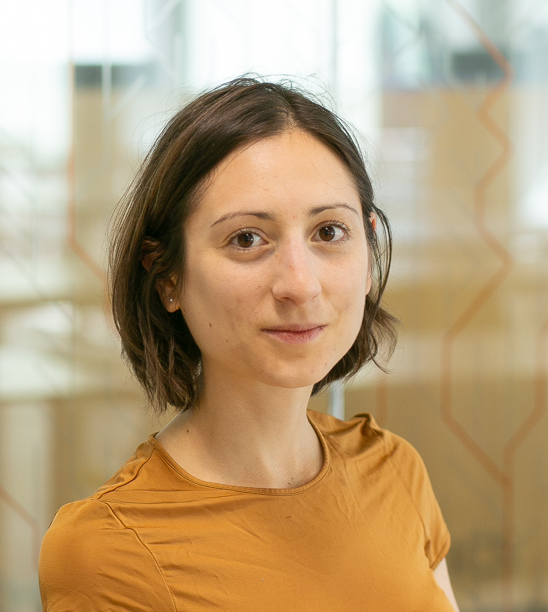

## Upcoming Meetings, Conferences, and Workshops

### ISBA sponsored or endorsed events

- [The Bayesian Young Statisticians Meeting (BAYSM) 2026](https://baysm2026.github.io/), 26–27 June 2026, Chiba University, Japan. The keynote speakers will be Prof. Kerrie Mengersen and Prof. Kengo Kamatani.
- [4$^{th}$ Bayesian Nonparametrics (BNP) Networking Workshop](https://bnpnetworking2026.github.io/), 6–10 July 2026, Seoul, South Korea.
- [The 9th Eastern Asia Chapter Conference (EAC-ISBA 2026)](http://eac-isba.ms.ynu.edu.cn/), 23–25 July 2026, Yunnan University in Kunming, China.
- [16th European Seminar on Bayesian Econometrics (ESOBE)](https://esobe2026.github.io/), 27–28 August 2026, LUISS University, Rome, Italy.
- [The Bayesian Biostatistics Meeting (BAYES) 2026](https://www.bayes-pharma.org/), 21–23 October 2026, Leiden, The Netherlands. This meeting is an annual gathering of biostatisticians interested in using Bayesian methods in life science and public health settings. The meeting features a half-day short course, 8 plenary speakers, a large number of contributed talks, and a panel discussion.
- [Rethinking the Role of Bayesianism in the Age of Modern AI Workshop](https://workshops.inf.ed.ac.uk/ml/bayesai/), 26–30 October 2026, Edinburgh, UK.
- [International Conference on Statistics, Data Science, and Computing for the Environment and Climate Change (LACSC-TIES-EnviBayes-EnvrASA) 2026](https://isi-web.org/event-detail/664), 7–11 December 2026, Mexico City, Mexico.
- [International Statistical Ecology Conference (ISEC 2027)](https://statisticalecology.org/#Workshops), 8–15 January 2027, Mérida, Yucatán, México. This is the main international gathering of statistical ecologists and an inclusive interdisciplinary conference at the interface between statistics and ecology. This event is composed of 2-day workshops (8–9 January) followed by the main conference (10–15 January).
- [VIII Latin America Congress on Bayesian Statistics and 18th Brazilian Meeting of Bayesian Statistics](https://cobalebeb2027.softaliza.com.br/), 1–5 March 2027, Armação de Búzios, Rio de Janeiro, Brazil. This biannual meeting’s primary goal is to strengthen the integration of Latin American researchers working in Bayesian Statistics and enhance their visibility and impact by fostering the convergence of different communities around shared challenges and advances. Deadline for contributed talks and posters submissions: 30 August 2026.

### Other events

- [$10^{th}$ Bayesian, Fiducial, and Frequentist Statistics (BFF) conference](https://bffconference.github.io/bff-salzburg-2026/), 10–11 July 2026, Salzburg, Austria.
- [Institute of Mathematical Statistics Annual Meeting 2026](https://ims2026.github.io/IMS2026/), 6–9 July 2026, Salzburg, Austria.
- [European Meeting of Statisticians 2026](https://ems26.org/), 24–28 August 2026, Lugano, Switzerland.
- [Joint Statistical Meetings 2026](https://ww2.amstat.org/meetings/jsm/2026/), 1–6 August 2026, Boston, USA.
- [Royal Statistical Society International Conference 2026](https://rss.org.uk/training-events/conference2026/), 7–10 September 2026, Bournemouth, UK. This is a well-attended event by professionals, researchers, students and everyone interested in the cutting edge of statistical methodology and the impactful application of statistics and data science. Deadline for poster presentations: 19 June.
- [12th International Conference on Soft Methods in Probability and Statistics](https://conference.unisalento.it/event/14/), 15–18 September 2026, Lecce, Italy. This conference is a biennial event gathering researchers exploring established and emerging approaches in soft probability and statistics.
- [Mathematics in Sciences, Engineering, and Economics (MathSEE) symposium](https://indico.kit.edu/event/5571/overview), 28–30 September 2026, Karlsruhe, Germany. This symposium features 8 plenary speakers and 7 sessions on topics such as inverse problems and optimization, Bayesian structure learning, and dependence modeling. Deadline for submitting contributed talks: July 31.
- [Bayesian Methods for the Social Sciences (BMSS-III)](https://bayesforshs3.sciencesconf.org/), 9–11 December 2026. The event will gather statisticians and social scientists around the theme of Bayesian statistical methods for the social sciences. It is the third edition of the workshop. The first was held in Paris in October 2022, and BMSS-II took place in Amsterdam in October 2024.
- [IMS International Conference on Statistics and Data Science (ICSDS) 2026](https://sites.google.com/view/ims-icsds2026/home), 15–18 December 2026, Split, Croatia. This annual conference brings together researchers in statistics and data science from academia, industry, and governments. Deadline for student award applications: 30 September.
- [International Indian Statistical Association (IISA) 2026 conference](https://www.intindstat.org/conference2026/index), 26–30 December 2026, Varanasi, India. The conference’s program includes short courses, contributed and invited sessions, and four plenary speakers. Deadline for poster and abstract submissions: 1 August.
- [Bayesian Structural Learning (BAYST) Workshop](https://sites.google.com/view/bayst2027), 1–3 March 2027, Karlsruhe, Germany. This workshop aims to bridge recent advances in Bayesian structural learning with applied sciences, fostering scientific discussion and collaboration between theoretical and applied researchers.

# TEACHING BAYES

Federica Zoe Ricci

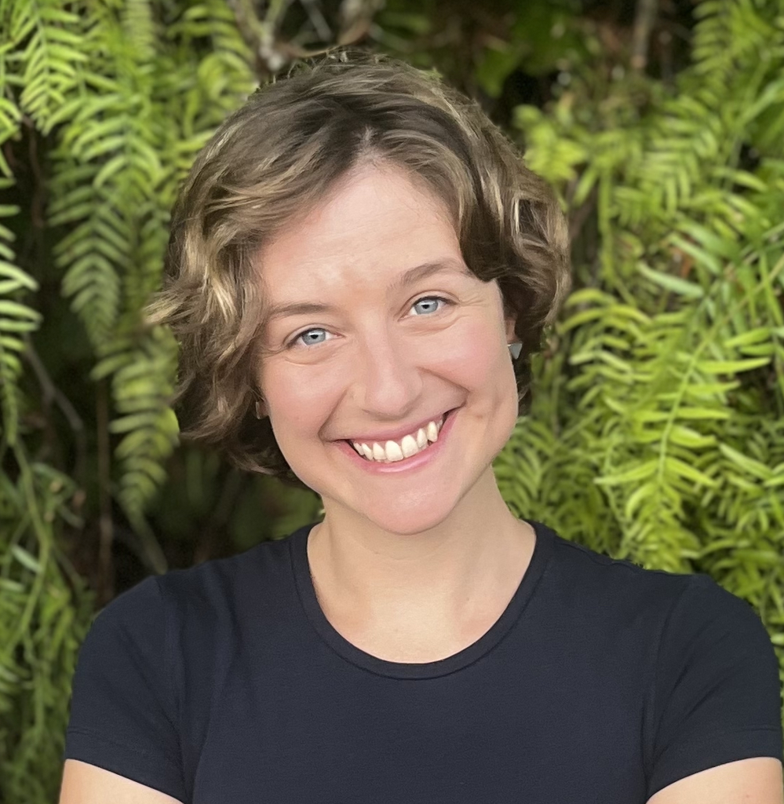

In the summers of 2023 and 2024, ISBA members **Mine Dogucu, Monika Hu and Amy Herring** ran *Bayes BATS*, a program aimed at **widening the teaching of Bayesian statistics in STEM** by training approx. 40 STEM professors, many of whom were new to Bayesian statistics. For this edition of our bulletin, 10 participants reflected on their successes and challenges since receiving the training, and shared some resources that they created. Below you can find a **summary of survey responses**, and can **learn about news and upcoming events** related to teaching Bayesian statistics.

### Reflections and resources from a new cohort of Bayesian educators

#### Successes

The program provided most respondents with the confidence and competencies to **add new Bayesian courses** to their institutional offerings, or to **modify existing courses to include Bayesian methods** alongside frequentist approaches. Often, their students are excited to learn Bayesian ideas and have fun with the learning activities that participants co-developed. Some direct quotes are:

> “*Once you explain how things work, it’s like a light bulb goes on and it makes (even more) sense than what they already knew.*”

> “*One of my favorite end-of-semester reflection questions asks students whether they see themselves as more Bayesian, or more frequentist. Their responses often lead to thoughtful discussions about the philosophical foundations of statistics.*”

Finally, some trainees have began **using Bayesian methods in their own research**.

#### Challenges

Three main challenges were highlighted. First, a difficulty in **allocating sufficient time** to introduce new Bayesian material without sacrificing core requirements of existing, heavy-frequentist curricula. Second, dealing with **push-back from some colleagues** who are skeptical about Bayesian methods or about their usefulness for job prospects, particularly in business and economics programs. Third, overcoming students’ intimidation by the **perceived difficulty of Bayesian concepts and cognitive load of learning programming languages** like R. Participants also reported that the main conceptual challenge is teaching how to choose priors.

#### What training or resources would you like to see?

Several respondents would love to receive more **training on intermediate Bayesian analysis** topics, including modeling, prior selection, and model validation:

> “*[…] any training opportunities that help professors and/or students move from introductory statistics topics to more complex [Bayesian] analyses*”

There is also a need for more resources for teaching **Bayesian computation** and to help students **connect theoretical Bayesian concepts to modern applications** — especially examples that are accessible to undergraduate students.

#### Resources created

Respondents were happy to share some of the resources that they created:

- A course in **Applied Bayesian Analysis** ([link](https://samanthaseals.github.io/STA6349Su26/), by S. Seals).
- An activity to introduce the **Bayesian workflow with applications in biology, environmental science and criminal justice** ([link](https://agmath.github.io/IntroductoryBayesInContext/index.html), by A. Gilbert, K. Dureya and L. Lambert).
- An activity to teach the **Beta-Binomial model** through a quiz where students try to **tell whether a headline came from CNN (a real news site) or The Onion (a fake, satirical news site)** ([link](https://bayes-bats.github.io/cnn-onion/bayesian-activity/cnn-onion-beta-binomial.html), by L. Baker, J. Scott and M. Dogucu).
- An activity to teach **Bayesian reasoning and conditional probability** through team work ([link](https://arxiv.org/abs/2606.08660), by C. Yu and A. Ebeling).
- An activity to **compare frequentist and Bayesian analyses using The Climate and Economic Justice Screening Tool** ([link](https://github.com/bayes-bats/tier2-freq-bayes/tree/main), by S. Langehennig and Z. del Rosario).

Some participants would love to find new collaborators to co-develop Bayesian teaching materials: please reach out to fricci1@swarthmore.edu if you’d like to be put in contact with them!

### BERaP mixer at ISBA

Come meet members of the Bayesian Education Research and Practice section at the **BERaP mixer** event during the 2026 ISBA World Conference in Nagoya! It will take place from 6:30 to 8 pm on July 1, 2026 (Wed), at the Izakaya Revolution Yotteba Meieki 3 Chome. Please use [this link](https://forms.gle/UpyDDY3PAQYA2tVK7) to RSVP.

### News and upcoming opportunities

- A new **textbook** for learning Bayesian methods was published: *Bayesian Workflow*, by Andrew Gelman, Aki Vehtari and Richard McElreath. Here is a link to the [accompanying website](https://avehtari.github.io/Bayesian-Workflow/).
- The Canadian Journal of Statistics invites **manuscript submissions** for a special issue on *Modern Issues in Statistics Education*. Check out their [call for papers](https://www.statisticsviews.com/call-for-papers-special-issue-on-modern-issues-in-statistics-education/) (paper submission deadline: 15 October 2026).
- The ASA Section on Statistics and Data Science Education is inviting interested mentees and mentors to apply to its **mentoring program**, aiming to provide career advice and mentoring to statistics and data science educators. This year, ASA membership is *not* required to participate. Applications received by August 7 will receive priority. See the [application form](https://docs.google.com/forms/d/e/1FAIpQLScTbGPck8lW8U78RmkXROv9ZFXSqAC9sSgxlKoQ3o3q09YQnQ/viewform).
- Every year, the ASA Section on Statistics and Data Science Education grants **funding** to promote educational initiatives. The application deadline is usually in mid-August. If you are interested in applying, check out their initiatives webpage.

### In case you missed it

- BERaP hosted a webinar on **Teaching Bayesian Statistics in Modern Sports Analytics**, featuring Assistant Teaching Professor Ron Yurko from Carnegie Mellon University. Recording and slides can be accessed [here](https://berap-isba.github.io/events.html).
- The [2026 Electronic Conference on Teaching Statistics](https://www.causeweb.org/cause/ecots/ecots26/) was held online. The theme was **Sparking Joy and Discovery In a World of AI**. You can visit the conference website to find out what was discussed and what resources were shared. You can find inspiration and resources for your own teaching — I especially recommend you to check out the posters!

### Executive Committee

**President:** Antonio Lijoi  
**Past President:** Michele Guindani  
**President Elect:** Judith Rousseau  
**Treasurer:** Yanxun Xu  
**Executive Secretary:** Xinyi Xu

### Program Council

**Chair:** Yang Ni  
**Vice Chair:** David Frazier  
**Past Chair:** Sameer K. Deshpande

### Social Media Team

Andrew Brown, Julyan Arbel, Clara Grazian, Collin Cademartori

### Board Members

**2026–2028:**  
Alejandra Avalos Pacheco, David Dahl, Beatrice Franzolini, Stéphanie van der Pas

**2025–2027:**  
Sinead Williamson, Clara Grazian, Sally Paganin, David Rossell

**2024–2026:**  
Antonio Canale, Daniele Durante, Lucia Paci, Georgia Papadogeorgou

### Editorial Board

#### Editor

*Francesco Denti*

#### Associate Editors

**Features**  
*Anton Westveld*  
**News of the World**  
*Déborah Sulem*  
**Teaching Bayes**  
*Federica Zoe Ricci*